# Download and clean benchmark data

November 27, 2019

```r
knitr::opts_chunk$set(
    echo = TRUE,
    message = FALSE,
    warning = FALSE,
    message = FALSE
)

# Load packages
suppressPackageStartupMessages({
  library(here)
  library(janitor)
  library(knitr)
  library(kableExtra)
  library(rnaturalearth)
  library(tidyverse)
})

source(here("code", "file_names.R"))
```

# About the data

In 2005,Bouwman et al published a paper titled [“Exploring changes in river nitrogen export to the world’s oceans”](https://doi.org/10.1029/2004GB002314). As part of their supplementary maeterials, they include “nitrogen removal in wastewater treatment, and human N emission” for each county at different points in time. Here, we will download their supplementary file and wrangle it to put it into a useful format.

Their supplementary materials can be found athttps://agupubs.onlinelibrary.wiley.com/action/downloadSupplement?doi=10.1029%2F2004GB002314&file=gbc1123-sup-0002-auxiliary_material_data.txt.

# Download the data

We could technically read the data directly from the url. But just in case, let’s download a raw version of the data first. We’ll download this data into the shared data folder on `mazu`. Per [this GH issue](https://github.com/OHI-Science/wastewater_issues/issues/6), that is `/home/shares/ohi/git-annex/land-based/wastewater/`. In this path, I’ll save the raw data into the `raw_data` folder, and the clean data into the `interim` data folder.

```r
# Define URL
url <- "https://agupubs.onlinelibrary.wiley.com/action/downloadSupplement?doi=10.1029%2F2004GB002314&file=gbc1123-sup-0002-auxiliary_material_data.txt"

# Download adn save the file
download.file(url = url, destfile = bouwman_raw_fn, mode = "wb")
```

# Cleaning the data

First, let’s read in the data. After inspecting it directly in the [URL](https://agupubs.onlinelibrary.wiley.com/action/downloadSupplement?doi=10.1029%2F2004GB002314&file=gbc1123-sup-0002-auxiliary_material_data.txt), I know the following:

- I need to skip the first 8 lines to get to the data
- The deta has double headers: one with variable names and another one for years
- The data have 35 columns, but the first header has `Country` and `iso_code` split, while it should be `Country_iso_code`
- In the second header, the first two columns are `#`, indicating that they are empty.

Let’s fix all these.

## Propper column neames

```r
# Get the first header line
header_1 <- scan(file = bouwman_raw_fn, nlines = 1, skip = 7, what = character())
# Modify the first value of this
header_1 <- c(paste(header_1[1], header_1[2], sep = "_"), #combine the first two elements into one
              header_1[-c(1:2)]) #Add the rest

# Get the second header line
header_2 <- scan(file = bouwman_raw_fn, nlines = 1, skip = 8, what = character())
# Replace the "#" for empty characters
header_2[1:2] <- ""

# Combine the first and second rows
header <- paste0(header_1, header_2)

# Use janitor to clean these names
header <- make_clean_names(header)

# Inspect our headers
header
```

```
##  [1] "country_iso_code"
##  [2] "country_name"
##  [3] "population_1000_inhabitants_1970"
##  [4] "population_1000_inhabitants_1980"
##  [5] "population_1000_inhabitants_1990"
##  [6] "population_1000_inhabitants_1994"
##  [7] "population_1000_inhabitants_1995"
##  [8] "population_1000_inhabitants_1998"
##  [9] "population_1000_inhabitants_2015"
## [10] "population_1000_inhabitants_2030"
## [11] "urbanization_percent_1970"
## [12] "urbanization_percent_1990_95"
## [13] "urbanization_percent_2000"
## [14] "urbanization_percent_2020"
## [15] "urbanization_percent_2030"
```

[output cut: 20 more lines]

```r
#
bouwman <- read_delim(file = bouwman_raw_fn, delim = "\t", skip = 9, col_names = header)

bouwman
```

```
## # A tibble: 227 x 35
##    country_iso_code country_name population_1000… population_1000…
##               <dbl> <chr>                   <dbl>            <dbl>
##  1              124 Canada                  21324            24593
##  2              666 Saint_Pierr…                5                6
##  3              840 United_Stat…           210111           230406
##  4              136 Cayman_Isla…               10               17
##  5              188 Costa_Rica               1731             2284
##  6              192 Cuba                     8520             9710
##  7              212 Dominica                   70               74
##  8              214 Dominican_R…             4423             5697
##  9              222 El_Salvador              3598             4547
## 10               28 Antigua_and…               57               61
## # … with 217 more rows, and 31 more variables:
## #   population_1000_inhabitants_1990 <dbl>,
## #   population_1000_inhabitants_1994 <dbl>,
## #   population_1000_inhabitants_1995 <dbl>,
## #   population_1000_inhabitants_1998 <dbl>,
## #   population_1000_inhabitants_2015 <dbl>,
## #   population_1000_inhabitants_2030 <dbl>, urbanization_percent_1970 <dbl>,
## #   urbanization_percent_1990_95 <dbl>, urbanization_percent_2000 <dbl>,
## #   urbanization_percent_2020 <dbl>, urbanization_percent_2030 <dbl>,
## #   gdp_1995us_capita_1970 <chr>, gdp_1995us_capita_1990_95 <chr>,
## #   gdp_1995us_capita_2000 <chr>, gdp_1995us_capita_2020 <chr>,
## #   gdp_1995us_capita_2030 <chr>,
## #   urban_population_with_access_to_improved_sanitation_percent_1970 <dbl>,
## #   urban_population_with_access_to_improved_sanitation_percent_1990_95 <dbl>,
## #   urban_population_with_access_to_improved_sanitation_percent_2030 <dbl>,
## #   rural_population_with_access_to_improved_sanitation_percent_1970 <dbl>,
## #   rural_population_with_access_to_improved_sanitation_percent_1990_95 <dbl>,
## #   rural_population_with_access_to_improved_sanitation_percent_2030 <dbl>,
## #   population_connected_to_sewerage_percent_1970 <dbl>,
## #   population_connected_to_sewerage_percent_1990_95 <dbl>,
## #   population_connected_to_sewerage_percent_2030 <dbl>,
## #   n_removal_in_wastewater_treatment_plants_percent_1970 <dbl>,
## #   n_removal_in_wastewater_treatment_plants_percent_1990_95 <dbl>,
## #   n_removal_in_wastewater_treatment_plants_percent_2030 <dbl>,
## #   n_emission_kg_inhabitant_year_1970 <dbl>,
## #   n_emission_kg_inhabitant_year_1990_95 <dbl>,
## #   n_emission_kg_inhabitant_year_2030 <dbl>
```

## Keeping what matters

The table above has a lot of information, and most of it may not be relevant. First, let’s keep only the columns that are relevant and for 1995. Then, I’ll rename some columns to have more intuitive names.

```r
bouwman <- bouwman %>%
  select(country_iso_code, country_name, contains("95"), -contains("gdp")) %>%
  rename(country_iso = country_iso_code,
         pop_ths = population_1000_inhabitants_1995,
         pct_urban = urbanization_percent_1990_95,
         pct_urban_access_sanitation = urban_population_with_access_to_improved_sanitation_percent_1990_95,
         pct_rural_access_sanitation = rural_population_with_access_to_improved_sanitation_percent_1990_95,
         pct_pop_connected_sewerage = population_connected_to_sewerage_percent_1990_95,
         pct_n_removal_treatment_plants = n_removal_in_wastewater_treatment_plants_percent_1990_95,
         n_emmission_kg_inhabitant = n_emission_kg_inhabitant_year_1990_95)

bouwman
```

```
## # A tibble: 227 x 9
##    country_iso country_name pop_ths pct_urban pct_urban_acces… pct_rural_acces…
##          <dbl> <chr>          <dbl>     <dbl>            <dbl>            <dbl>
##  1         124 Canada         29354        77              100               99
##  2         666 Saint_Pierr…       6        86              100              100
##  3         840 United_Stat…  268744        76              100              100
##  4         136 Cayman_Isla…      31       100               86               43
##  5         188 Costa_Rica      3554        47               89               97
##  6         192 Cuba           10964        75               96               75
##  7         212 Dominica          71        69               86               75
##  8         214 Dominican_R…    7697        62               70               60
##  9         222 El_Salvador     5670        45               88               65
## 10          28 Antigua_and…      64        36               98               94
## # … with 217 more rows, and 3 more variables: pct_pop_connected_sewerage <dbl>,
## #   pct_n_removal_treatment_plants <dbl>, n_emmission_kg_inhabitant <dbl>
```

# As a map

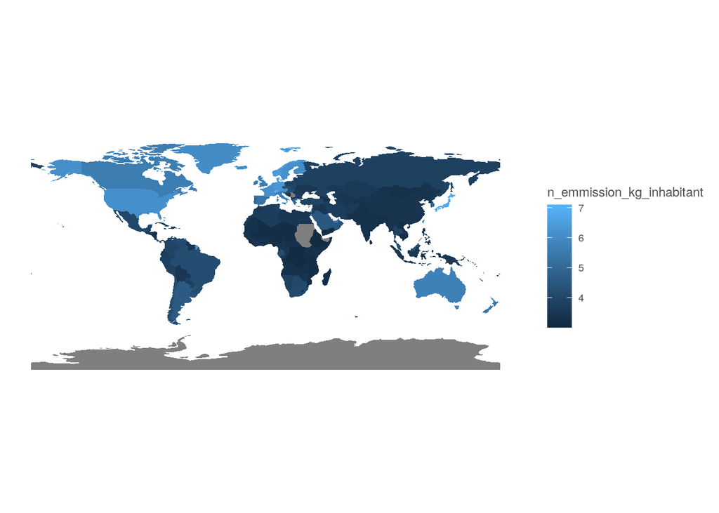

```r
countries <- ne_countries(returnclass = "sf") %>%
  mutate(iso_n3 = as.numeric(iso_n3)) %>%
  left_join(bouwman, by = c("iso_n3" = "country_iso"))

ggplot(data = countries,
       mapping = aes(fill = n_emmission_kg_inhabitant)) +
  geom_sf(size = 0, color = "black") +
  startR::ggtheme_map()
```

# Export the data

```r
write.csv(x = bouwman,
          file = bouwman_fn,
          row.names = F)
```

# Reproducibility

## System info

```r
Sys.info()
```

```
##                                        sysname
##                                        "Linux"
##                                        release
##                            "4.4.0-164-generic"
##                                        version
## "#192-Ubuntu SMP Fri Sep 13 12:02:50 UTC 2019"
##                                       nodename
##                                         "mazu"
##                                        machine
##                                       "x86_64"
##                                          login
##                                      "unknown"
##                                           user
##                                  "jvillasenor"
##                                 effective_user
##                                  "jvillasenor"
```